# Emotions and Psychological Distance Analysis

Desmond Ong

February 29, 2016

The following data file accompanies Ong, Goodman, & Zaki, which is in press at Emotion. It contains all the code needed to reproduce the analyses reported in the paper.

# Introduction

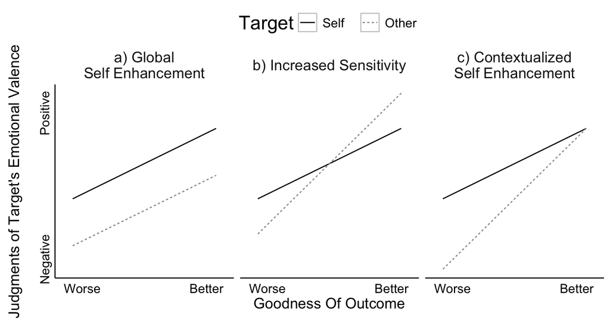

Top: Figure 1 in paper.  
Predictions. On the vertical axis are attributions of happiness following an outcome, and on the horizontal axes are how “good” or “bad” the outcome is. Overall, happiness attributions should increase with the “goodness” of the outcome. Predictions for attributions to oneself are given in solid lines, while attributions to others are given in dashed lines. (a) Predictions from a simple “happier than average” bias that is context-independent. (b) Predictions from an “increased sensitivity” account: attributions to others are more sensitive to changes in the outcome. (c) Combining both (a) and (b).

# Study 1

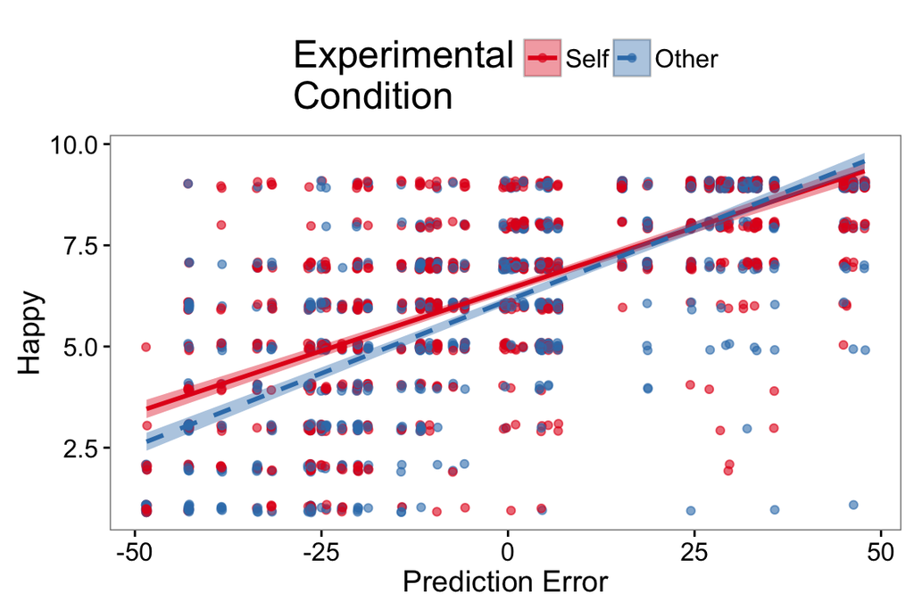

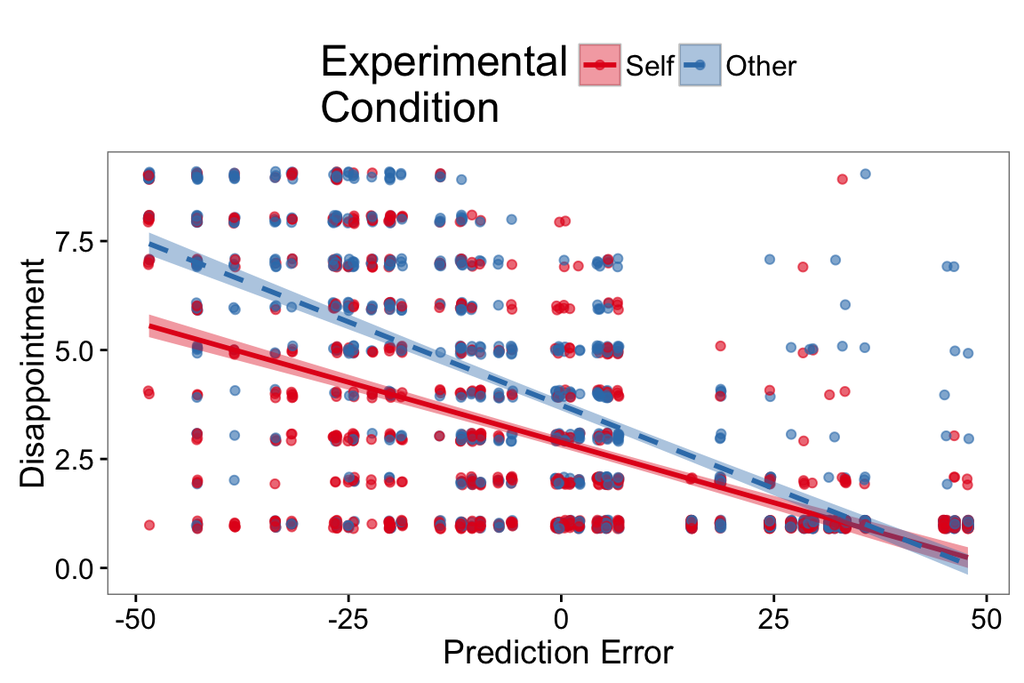

Top: Figure 3 in paper.  
Participants’ attributions of happiness and disappointment to themselves (in red) and others (blue) as a function of PE. Data points are jittered for visibility, with best linear fits overlaid.

#### Study 1 Results

| Emotion | Simple Effect b [95% CI] | t | p | Reward Sensitivity (Interaction) b [95% CI] | t | p | marginal R^2 | conditional R^2 |
| --- | --- | --- | --- | --- | --- | --- | --- | --- |
| Happy | -0.307 [-0.596, -0.018] | -2.085 | 0.038 | 0.015 [0.011, 0.019] | 7.066 | 0.000 | 0.534 | 0.762 |
| Content | 0.260 [-0.216, 0.736] | 1.069 | 0.286 | 0.016 [0.010, 0.021] | 5.753 | 0.000 | 0.310 | 0.694 |
| Positive Composite | -0.024 [-0.355, 0.306] | -0.145 | 0.885 | 0.015 [0.011, 0.019] | 7.310 | 0.000 | 0.477 | 0.756 |
| Sad | 0.643 [0.336, 0.949] | 4.110 | 0.000 | -0.024 [-0.028, -0.019] | -10.469 | 0.000 | 0.319 | 0.629 |
| Anger | 0.511 [0.221, 0.801] | 3.457 | 0.001 | -0.019 [-0.023, -0.016] | -10.588 | 0.000 | 0.161 | 0.577 |
| Disgust | 0.446 [0.190, 0.703] | 3.407 | 0.001 | -0.016 [-0.020, -0.012] | -8.045 | 0.000 | 0.168 | 0.507 |
| Disappointment | 0.877 [0.559, 1.195] | 5.402 | 0.000 | -0.025 [-0.030, -0.020] | -9.652 | 0.000 | 0.471 | 0.691 |
| Negative Composite | 0.620 [0.367, 0.873] | 4.803 | 0.000 | -0.021 [-0.024, -0.018] | -12.389 | 0.000 | 0.378 | 0.693 |
| Surprise | 0.748 [0.323, 1.173] | 3.446 | 0.001 | -0.005 [-0.011, 0.001] | -1.507 | 0.133 | 0.171 | 0.563 |
| Fear | 0.033 [-0.159, 0.225] | 0.334 | 0.739 | -0.001 [-0.003, 0.000] | -1.628 | 0.105 | 0.005 | 0.631 |

Top: Table 1 in paper.  
Study 1 results. Each row indicates the results of one model predicting one emotion (or emotion composite). Left: Coefficients on the simple effect of condition (i.e. the contrast Other-Self at PE=0) in the mixed models. Right: Reward sensitivity, or the coefficient on the Condition*PE interaction term in the mixed models. (n.s. not significant,* p<.05, ** p<.01, *** p<.001) Marginal and Conditional R^2 are reported, after Nakagawa and Schielzeth (2013)

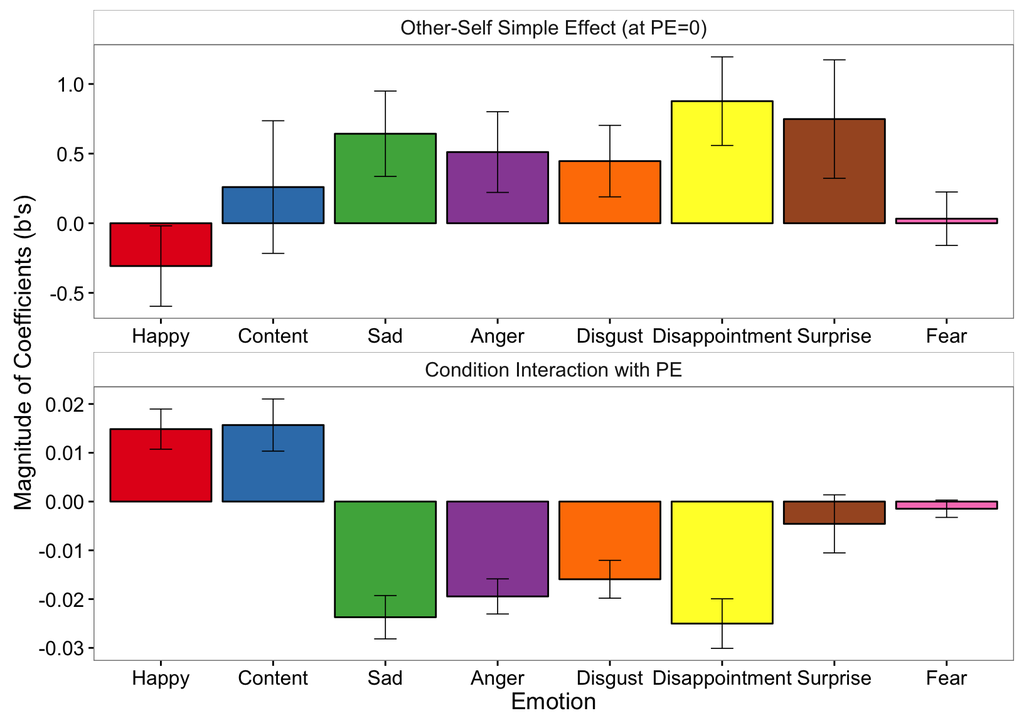

Top (not in paper): Graph of coefficients of individual emotions for Study 1. (Basically a graphical representation of the coefficients in Table 1). Error bars represent 95% CIs.

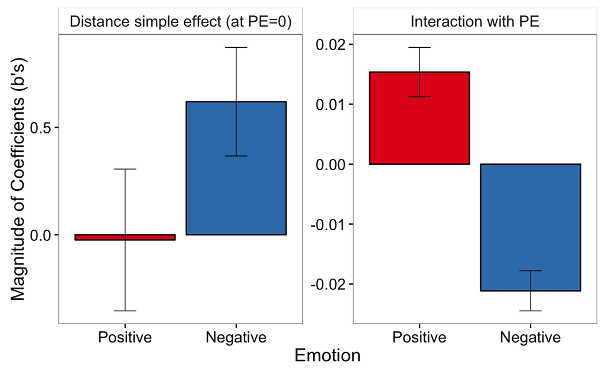

Top (not in paper): Similar graph, but only for the positive/engative emotion composites. Error bars are 95% CIs.

# Study 2

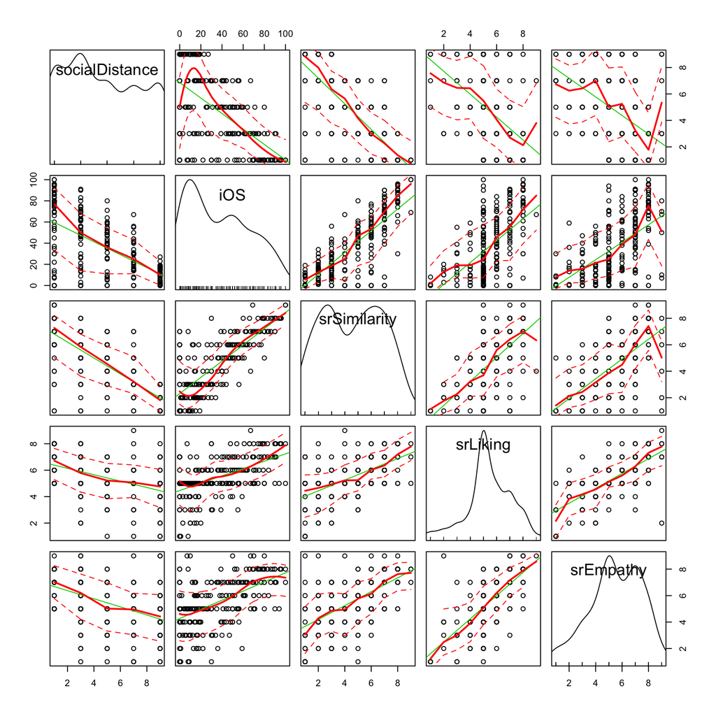

Top (not in paper): correlation plots of the manipulation checks with our manipualted socialDistance variable. iOS: Inclusion of Self in Other Scale. Others: Similarity, Liking, Empathy. See paper for details.

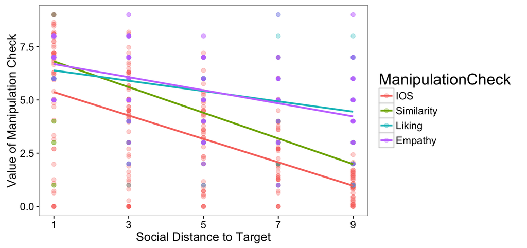

Top (not in paper): scatterplot of the manipulation checks against our manipualted socialDistance variable.

The manipulation checks confirmed that the psychological distance manipulation had the intended effect on participants’ subjective psychological distance to the target. The manipulated psychological distance was negatively correlated with participants’ ratings on the IOS (r=-0.5971799; t(236)=-11.4374363, p<.0001), similarity judgments (r=-0.7644347; t(236)=-18.2153689, p<.0001), liking judgments (r=-0.4577586; t(236)=-7.9095785, p<.0001), and empathy ratings with the target (r=-0.464729; t(236)=-8.0628809, p<.0001).

#### Study 2 Regression Results

| Emotion | Simple Effect b [95% CI] | t | p | Reward Sensitivity (Interaction) b [95% CI] | t | p | marginal R^2 | conditional R^2 |
| --- | --- | --- | --- | --- | --- | --- | --- | --- |
| Happy | -0.023 [-0.064, 0.018] | -1.1 | 0.273 | 0.001 [0, 0.002] | 3.31 | 0.001 | 0.586 | 0.790 |
| Content | -0.025 [-0.1, 0.05] | -0.653 | 0.514 | 0.001 [0, 0.002] | 2.56 | 0.011 | 0.271 | 0.642 |
| Positive Composite | -0.024 [-0.073, 0.025] | -0.945 | 0.346 | 0.001 [0, 0.002] | 3.35 | 0.001 | 0.493 | 0.756 |
| Sad | 0.051 [0.001, 0.1] | 2.01 | 0.046 | -0.001 [-0.002, 0] | -3.04 | 0.003 | 0.341 | 0.654 |
| Anger | 0.075 [0.023, 0.128] | 2.81 | 0.006 | -0.002 [-0.002, -0.001] | -5.26 | 0 | 0.209 | 0.612 |
| Disgust | 0.048 [-0.003, 0.099] | 1.84 | 0.067 | -0.001 [-0.001, 0] | -1.98 | 0.049 | 0.185 | 0.590 |
| Disappointment | 0.046 [-0.007, 0.099] | 1.7 | 0.091 | -0.001 [-0.002, 0] | -2.66 | 0.009 | 0.474 | 0.696 |
| Negative Composite | 0.055 [0.009, 0.101] | 2.33 | 0.021 | -0.001 [-0.002, -0.001] | -3.9 | 0 | 0.377 | 0.709 |
| Surprise | 0.08 [0.015, 0.145] | 2.42 | 0.017 | -0.001 [-0.002, 0] | -1.85 | 0.065 | 0.163 | 0.559 |
| Fear | 0.042 [0.003, 0.082] | 2.09 | 0.038 | 0 [-0.001, 0] | -0.324 | 0.747 | 0.033 | 0.544 |

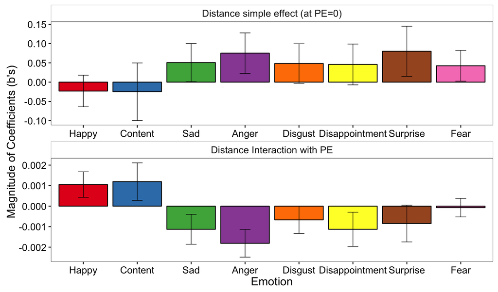

Top (not in paper): Graph of coefficients of individual emotions for Study 2. Error bars represent 95% CIs.

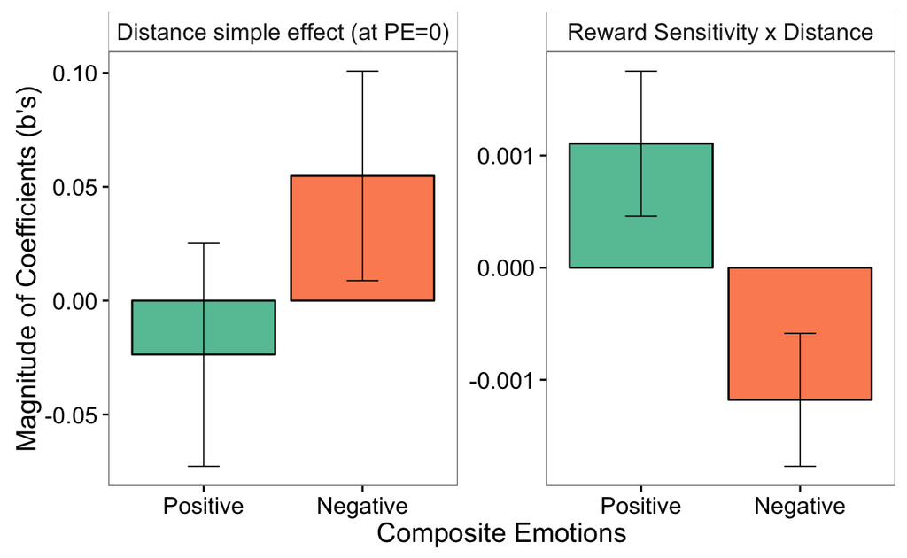

Top (Figure 4 in paper):  
Study 2 results: Left: Simple effect (i.e., the effect of social distance at PE=0). Right: Reward sensitivity across social distance (i.e., interaction of social distance with PE). Error bars represent 95% Confidence Intervals.

# Study 3

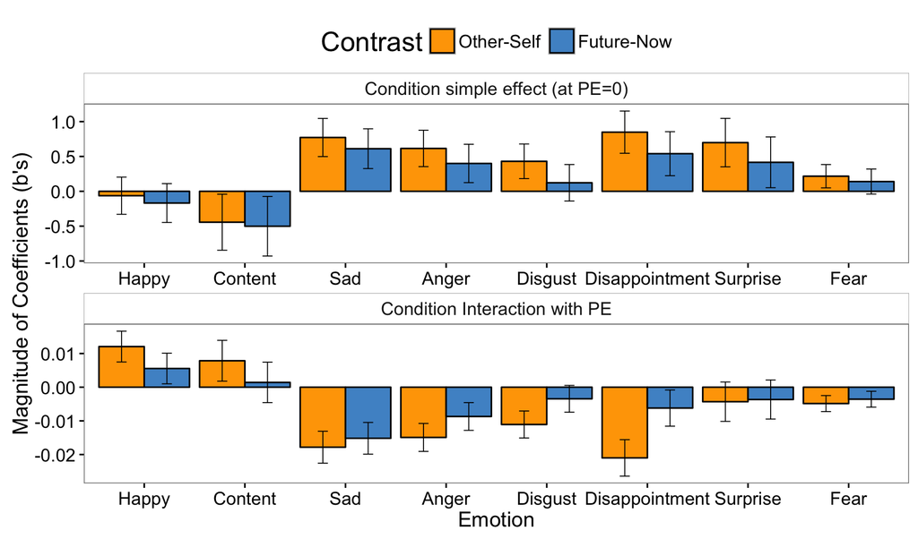

Top (not in paper): Graph of coefficients of individual emotions for Study 3. Error bars represent 95% CIs.

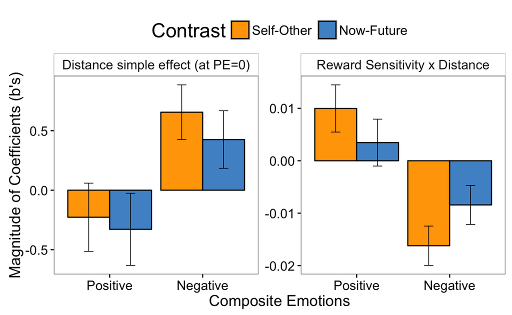

Top (Figure 5 in paper):  
Study 3 results: Left: Simple effect by distance (i.e., the effect of the distance manipulations at PE=0). Right: Reward sensitivity across psychological distance (i.e., the interactions of the two distance manipulations with PE). Error bars represent 95% Confidence Intervals.

| Emotion | Three way interaction b [95% CI] | t | p | marginal R^2 | conditional R^2 |
| --- | --- | --- | --- | --- | --- |
| Happy | -0.009 [-0.015, -0.002] | -2.57 | 0.011 | 0.473 | 0.714 |
| Content | -0.009 [-0.018, -0.001] | -2.17 | 0.031 | 0.199 | 0.590 |
| Positive Composite | -0.009 [-0.015, -0.003] | -2.75 | 0.007 | 0.390 | 0.689 |
| Sad | 0.01 [0.003, 0.017] | 2.97 | 0.003 | 0.275 | 0.586 |
| Anger | 0.002 [-0.004, 0.008] | 0.703 | 0.483 | 0.167 | 0.551 |
| Disgust | -0.004 [-0.009, 0.002] | -1.3 | 0.195 | 0.152 | 0.528 |
| Disappointment | 0.011 [0.003, 0.018] | 2.73 | 0.007 | 0.398 | 0.635 |
| Negative Composite | 0.005 [0, 0.01] | 1.78 | 0.077 | 0.322 | 0.641 |
| Surprise | -0.001 [-0.009, 0.008] | -0.138 | 0.89 | 0.167 | 0.545 |
| Fear | 0 [-0.003, 0.004] | 0.134 | 0.893 | 0.026 | 0.537 |

Top (not in paper): Additional Data on 3 way (PE x social x temporal) interaction in Study 3.

## Supplemental Materials

| Emotion | Simple Effect of SOCIAL DISTANCE b [95% CI] | t | p | Reward Sensitivity (Interaction) of SOCIAL DISTANCE b [95% CI] | t | p | Simple Effect of TEMPORAL DISTANCE b [95% CI] | t | p | Reward Sensitivity (Interaction) of TEMPORAL DISTANCE b [95% CI] | t | p |
| --- | --- | --- | --- | --- | --- | --- | --- | --- | --- | --- | --- | --- |
| Happy | -0.063 [-0.33, 0.204] | -0.463 | 0.644 | 0.012 [0.007, 0.017] | 5.17 | 0 | -0.168 [-0.447, 0.11] | -1.18 | 0.238 | 0.006 [0.001, 0.01] | 2.4 | 0.018 |
| Content | -0.443 [-0.845, -0.041] | -2.16 | 0.032 | 0.008 [0.002, 0.014] | 2.54 | 0.012 | -0.501 [-0.928, -0.074] | -2.3 | 0.023 | 0.001 [-0.005, 0.007] | 0.467 | 0.641 |
| Positive Composite | -0.227 [-0.514, 0.059] | -1.55 | 0.122 | 0.01 [0.005, 0.014] | 4.34 | 0 | -0.329 [-0.632, -0.026] | -2.13 | 0.034 | 0.003 [-0.001, 0.008] | 1.52 | 0.131 |
| Sad | 0.772 [0.499, 1.04] | 5.54 | 0 | -0.018 [-0.023, -0.013] | -7.37 | 0 | 0.611 [0.326, 0.897] | 4.2 | 0 | -0.015 [-0.02, -0.01] | -6.32 | 0 |
| Anger | 0.615 [0.354, 0.876] | 4.62 | 0 | -0.015 [-0.019, -0.011] | -7.05 | 0 | 0.4 [0.124, 0.675] | 2.85 | 0.005 | -0.009 [-0.013, -0.005] | -4.14 | 0 |
| Disgust | 0.43 [0.182, 0.679] | 3.4 | 0.001 | -0.011 [-0.015, -0.007] | -5.42 | 0 | 0.122 [-0.139, 0.384] | 0.917 | 0.36 | -0.003 [-0.007, 0.001] | -1.7 | 0.092 |
| Disappointment | 0.849 [0.545, 1.15] | 5.49 | 0 | -0.021 [-0.026, -0.016] | -7.6 | 0 | 0.54 [0.224, 0.855] | 3.35 | 0.001 | -0.006 [-0.012, -0.001] | -2.26 | 0.025 |
| Negative Composite | 0.655 [0.425, 0.885] | 5.58 | 0 | -0.016 [-0.02, -0.012] | -8.49 | 0 | 0.426 [0.183, 0.668] | 3.44 | 0.001 | -0.008 [-0.012, -0.005] | -4.44 | 0 |
| Surprise | 0.699 [0.351, 1.05] | 3.94 | 0 | -0.004 [-0.01, 0.002] | -1.44 | 0.151 | 0.416 [0.052, 0.78] | 2.24 | 0.026 | -0.004 [-0.009, 0.002] | -1.24 | 0.218 |
| Fear | 0.217 [0.049, 0.384] | 2.54 | 0.012 | -0.005 [-0.007, -0.002] | -4 | 0 | 0.14 [-0.039, 0.319] | 1.53 | 0.128 | -0.004 [-0.006, -0.001] | -2.96 | 0.003 |